# Lab Five: Wide and Deep Networks

Members:  
CSE 5324:Shenxiao Mei, Samuel Lefcourt  
CSE 7324: Chenming Cui, Zeqi Guo

## Introduction

There are three places a human being has to go in his/her life; They are home, school and bank. While we are using banks to make deposits or borrow loans. Banks are watching our statements and credits history. Banks use a client's personal information, such as income, or the duration of a phone call to determine if this client would be willing to subscribe a term deposit. In this lab, we will use a dataset of bank clients. The data is related with direct marketing campaigns (phone calls) of a Portuguese banking institution. The classification goal is to predict if the client will subscribe a term deposit (variable y).

**Dataset Source: https://www.kaggle.com/henriqueyamahata/bank-marketing**

## Preparation

```python
import pandas as pd
import numpy as np

print('Pandas:', pd.__version__)
print('Numpy:',np.__version__)

df = pd.read_csv('data/bank-full.csv')

df.info()
df.head()
```

```
Pandas: 0.24.2
Numpy: 1.16.2
<class 'pandas.core.frame.DataFrame'>
RangeIndex: 45211 entries, 0 to 45210
Data columns (total 17 columns):
age          45211 non-null int64
job          45211 non-null object
marital      45211 non-null object
education    45211 non-null object
default      45211 non-null object
balance      45211 non-null int64
housing      45211 non-null object
loan         45211 non-null object
contact      45211 non-null object
day          45211 non-null int64
month        45211 non-null object
duration     45211 non-null int64
campaign     45211 non-null int64
pdays        45211 non-null int64
previous     45211 non-null int64
poutcome     45211 non-null object
y            45211 non-null object
dtypes: int64(7), object(10)
memory usage: 5.9+ MB
```

|  | age | job | marital | education | default | balance | housing | loan | contact | day | month | duration | campaign | pdays | previous | poutcome | y |
| --- | --- | --- | --- | --- | --- | --- | --- | --- | --- | --- | --- | --- | --- | --- | --- | --- | --- |
| 0 | 58 | management | married | tertiary | no | 2143 | yes | no | unknown | 5 | may | 261 | 1 | -1 | 0 | unknown | no |
| 1 | 44 | technician | single | secondary | no | 29 | yes | no | unknown | 5 | may | 151 | 1 | -1 | 0 | unknown | no |
| 2 | 33 | entrepreneur | married | secondary | no | 2 | yes | yes | unknown | 5 | may | 76 | 1 | -1 | 0 | unknown | no |
| 3 | 47 | blue-collar | married | unknown | no | 1506 | yes | no | unknown | 5 | may | 92 | 1 | -1 | 0 | unknown | no |
| 4 | 33 | unknown | single | unknown | no | 1 | no | no | unknown | 5 | may | 198 | 1 | -1 | 0 | unknown | no |

### Bank Client Data

- age(numeric): the age of clients
- job(categorical): the classes job of clients
- admin
- unknown
- unemployed
- management
- housemaid
- entrepreneur
- student
- bluecollar
- self-emploued
- retired
- technician
- services
- marital(categorical): marital status of clients
- married
- divorced(include divorced and widowed)
- single
- education(categorical): the education background of clients
- unknown
- secondary
- primary
- tertiary
- defult(categorical): if client already have credit in defult
- yes
- no
- balance(numeric)
- housing(categorical): if client have a housing loan
- yes
- no
- loan(categorical): if client have personal loan
- yes
- no

### Data related with the last contact of the current campaign:

- contact(categorical): type of cantact communication
- unknown
- telephone
- cellular
- day(numeric): last contact day of month
- month(categorical): last contact month of year
- jan
- feb
- mar
- apr
- may
- jun
- jul
- aug
- sep
- oct
- nov
- dec
- duration(numeric): last contact duration in seconds

### Other Attributes:

- campaign(numeric): number of contacts performed druing this campaign and for this client
- pdays(numeric): number of daus that passed by after the client was last contacted from a previous campaign(-1 means client was not previously contacted)
- previous(numeric): number of contacts performed before this campaign and for this client
- poutcome(categorical): outcome of the previous marketing campaign
- unknown
- other
- failure
- success
- y(categorical): if the client subscribed a term deposit
- yes
- no

### Data Cleaning

Firstly, we will check if there is gap or null data in the data, if there is we will take them out.

```python
if df.isnull().values.any():
    print('exist NULL data')
elif(df.isna().values.any()):
    print('exist NaN data')
else:
    print('no missing data')
```

```
no missing data
```

Then we will check if there is a duplicate set in our dataset.

```python
dup = ['age', 'job', 'education', 'balance', 'duration']
if 'True' in df.duplicated(subset=dup, keep=False):
    print('exist duplicate data')
else:
    print('no duplicate data')
```

```
no duplicate data
```

We have the values of "unknown" values in job and education columns. However, we do not need to clean them up because if we do, because, real cases could have the client that has unknown job the model might not classify well.

```python
print(df.groupby('job').size())
print('------------------------')
print(df.groupby('education').size())
```

```
job
admin.           5171
blue-collar      9732
entrepreneur     1487
housemaid        1240
management       9458
retired          2264
self-employed    1579
services         4154
student           938
technician       7597
unemployed       1303
unknown           288
dtype: int64
------------------------
education
primary       6851
secondary    23202
tertiary     13301
unknown       1857
dtype: int64
```

### Pre-Processing

In this part we will define our categorical headers and numeric headers, we will first transform all categorical headers into integers so that our keras model will recognize them as one hotted encoded categorical columns. We will also use the standard scalar to preprocess the numeric data to make all the data centered around 0 and have variance in the same order.  
According to **https://scikit-learn.org/stable/modules/generated/sklearn.preprocessing.StandardScaler.html**, "If a feature has a variance that is orders of magnitude larger that others, it might dominate the objective function and make the estimator unable to learn from other features correctly as expected".Here in our dataset, a few numeric data contain the exact "dominating" values. Therefore, we use the standard scalar to elimniate them.

```python
from sklearn.preprocessing import LabelEncoder
from sklearn.preprocessing import StandardScaler

from keras.layers import Dense, Activation, Input
from keras.layers import Embedding, Flatten, Concatenate
from keras.models import Model

encoders=dict()

categorical_headers=['job','marital','education','default','housing','loan','contact','month','poutcome']

numeric_headers = ["age", "balance", "day","duration","campaign","pdays","previous"]

df['target'] = (df['y'] == 'yes').astype(int)

df_train=df


for col in categorical_headers:
    df_train[col] = df_train[col].str.strip()
        # integer encoded variables
    encoders[col] = LabelEncoder() # save the encoder
    df_train[col+'_int'] = encoders[col].fit_transform(df_train[col])

# scale the numeric, continuous variables

for col in numeric_headers:
    df_train[col] = df_train[col].astype(np.float)

    ss = StandardScaler()
    df_train[col] = ss.fit_transform(df_train[col].values.reshape(-1, 1))

df_train.head()
```

|  | age | job | marital | education | default | balance | housing | loan | contact | day | ... | target | job_int | marital_int | education_int | default_int | housing_int | loan_int | contact_int | month_int | poutcome_int |
| --- | --- | --- | --- | --- | --- | --- | --- | --- | --- | --- | --- | --- | --- | --- | --- | --- | --- | --- | --- | --- | --- |
| 0 | 1.606965 | management | married | tertiary | no | 0.256419 | yes | no | unknown | -1.298476 | ... | 0 | 4 | 1 | 2 | 0 | 1 | 0 | 2 | 8 | 3 |
| 1 | 0.288529 | technician | single | secondary | no | -0.437895 | yes | no | unknown | -1.298476 | ... | 0 | 9 | 2 | 1 | 0 | 1 | 0 | 2 | 8 | 3 |
| 2 | -0.747384 | entrepreneur | married | secondary | no | -0.446762 | yes | yes | unknown | -1.298476 | ... | 0 | 2 | 1 | 1 | 0 | 1 | 1 | 2 | 8 | 3 |
| 3 | 0.571051 | blue-collar | married | unknown | no | 0.047205 | yes | no | unknown | -1.298476 | ... | 0 | 1 | 1 | 3 | 0 | 1 | 0 | 2 | 8 | 3 |
| 4 | -0.747384 | unknown | single | unknown | no | -0.447091 | no | no | unknown | -1.298476 | ... | 0 | 11 | 2 | 3 | 0 | 0 | 0 | 2 | 8 | 3 |

5 rows × 28 columns

```python
categorical_headers_ints = [x+'_int' for x in categorical_headers]
```

## Crossed Columns

We are going to make crossed columns to memorize relationships among some certain features. We choose education, job, housing and default because it is to our knowlegde that having certain dilemma can qualify a person for a certain job. People at a better occupation might have a bigger chance to have a housing or have a credit.

Since this dataset is described as Portugal bank call data, the relationship of the previous call duration and previous campaign result is valuable to our model, too. I would cut the duration into five intervals that share the same length to avoid the imbalance problem. I would implement this feature in the extra analysis part.

```python
cross_columns = [['education','job'],
                 ['housing', 'job'],
                 ['default','job']]

#Codes below will be used in extra I

# df['duration_class']=pd.cut(df['duration'],[-1,90,150,230,380,9999], labels=['very short','slightly short', 'mid','slightly long','very long'])
# categorical_headers=['job','marital','education','default','housing','loan','contact','month','poutcome','duration_class']
# categorical_headers_ints = [x+'_int' for x in categorical_headers]
# cross_columns_more=[['duration_class','poutcome']]
# print(df.groupby('duration_class').size())
```

### Evaluation Metrics

In this lab, we will use recall as our evaluation metric, the recall score is calculated by TP/(TP+FN). In our business case, accurate is not a good metric because we have an imbalance dataset. That is there are more people that choose not to subscribe the bank's deposit than those who will subscribe. Here, banks focus on if a client will subscribe a deposit and will do analysis and plan for them in ahead. Therefore, a recall is good metric because it can indicate the ratio of false negative because banks certainly do not want to waste more time on people that will not subscribe the deposit, but it is okay for them to miss a few clients because banks can still process their subscription after they actually subscribe the deposit.

```python
print(df.groupby('target').size())

from keras import backend as K

def recall_m(y_true, y_pred):
        true_positives = K.sum(K.round(K.clip(y_true * y_pred, 0, 1)))
        possible_positives = K.sum(K.round(K.clip(y_true, 0, 1)))
        recall = true_positives / (possible_positives + K.epsilon())
        return recall
```

```
target
0    39922
1     5289
dtype: int64
```

### Divide the data

For dividing the data we will use 80/20 because we have an enormous amount of samples in the dataset. We have over 45000 samples and we think this number is big enough to perform a 80/20 split. It is very unlikely to find just about 36000 samples that cannot represent the dataset. In the 20% part, we decide to perform another 80/20 split so that 80% is for validation and 20% is for test. That means we have 4% of test data and 4% of total 45000 is 1800, which is enough to express the performance of our models

```python
from sklearn.model_selection import train_test_split

print(df.shape)
df_y=df.target

# split original data to train and test
train, test = train_test_split(df,test_size=0.2,random_state=0)

# split original test data to validation data and test data
validation, test = train_test_split(test,test_size=0.2,random_state=0)

df_train=pd.DataFrame(train)
df_validation=pd.DataFrame(validation)
df_test=pd.DataFrame(test)

feature_columns = categorical_headers_ints+numeric_headers
X_train =  ss.fit_transform(df_train[feature_columns].values).astype(np.float32)
X_validation = ss.transform(df_validation[feature_columns].values).astype(np.float32)
X_test =  ss.transform(df_test[feature_columns].values).astype(np.float32)

y_train = df_train['target'].values.astype(np.int)
y_validation = df_validation['target'].values.astype(np.int)
y_test = df_test['target'].values.astype(np.int)

print(feature_columns)

X_train_num =  df_train[numeric_headers].values
X_validation_num = df_validation[numeric_headers].values
X_test_num = df_test[numeric_headers].values
```

```
(45211, 28)
['job_int', 'marital_int', 'education_int', 'default_int', 'housing_int', 'loan_int', 'contact_int', 'month_int', 'poutcome_int', 'age', 'balance', 'day', 'duration', 'campaign', 'pdays', 'previous']
```

## Modeling

Next, we are going to have fun with keras models. Create several combined wide and deep networks to classify your data using Keras. Visualize the performance of the network on the training data and validation data in the same plot versus the training iterations.

### First Model

This model contains a wide network that uses three pairs of cross columns  
This model also contains a deep network that has three layers with relu activation functions

```python
from keras.layers import concatenate

cross_columns = [['education','job'],
                 ['housing', 'job'],
                 ['default','job']]

embed_branches = []
X_ints_train_1 = []
X_ints_validation_1 = []
X_ints_test_1=[]
all_inputs_1 = []
all_wide_branch_outputs_1 = []

for cols in cross_columns:
    # encode crossed columns as ints for the embedding
    enc = LabelEncoder()

    # create crossed labels
    X_crossed_train = df_train[cols].apply(lambda x: '_'.join(x), axis=1)
    X_crossed_validation = df_validation[cols].apply(lambda x: '_'.join(x), axis=1)
    X_crossed_test = df_test[cols].apply(lambda x: '_'.join(x), axis=1)

    enc.fit(np.hstack((X_crossed_train.values,  X_crossed_validation.values)))
    X_crossed_train = enc.transform(X_crossed_train)
    X_crossed_validation = enc.transform(X_crossed_validation)
    X_crossed_test = enc.transform(X_crossed_test)
    X_ints_train_1.append( X_crossed_train )
    X_ints_validation_1.append( X_crossed_validation )
    X_ints_test_1.append(X_crossed_test)

    # get the number of categories
    N = max(X_ints_train_1[-1]+1) # same as the max(df_train[col])

    # create embedding branch from the number of categories
    inputs = Input(shape=(1,),dtype='int32', name = '_'.join(cols))
    all_inputs_1.append(inputs)
    x = Embedding(input_dim=N,
                  output_dim=int(np.sqrt(N)),
                  input_length=1, name = '_'.join(cols)+'_embed')(inputs)
    x = Flatten()(x)
    all_wide_branch_outputs_1.append(x)

# merge the branches together
wide_branch = concatenate(all_wide_branch_outputs_1, name='wide_concat')
wide_branch = Dense(units=1,activation='sigmoid',name='wide_combined')(wide_branch)

# reset this input branch
all_deep_branch_outputs = []
# add in the embeddings
for col in categorical_headers_ints:
    # encode as ints for the embedding
    X_ints_train_1.append( df_train[col].values )
    X_ints_validation_1.append( df_validation[col].values )
    X_ints_test_1.append(df_test[col].values)

    # get the number of categories
    N = max(X_ints_train_1[-1]+1) # same as the max(df_train[col])

    # create embedding branch from the number of categories
    inputs = Input(shape=(1,),dtype='int32', name=col)
    all_inputs_1.append(inputs)
    x = Embedding(input_dim=N,
                  output_dim=int(np.sqrt(N)),
                  input_length=1, name=col+'_embed')(inputs)
    x = Flatten()(x)
    all_deep_branch_outputs.append(x)

# also get a dense branch of the numeric features
all_inputs_1.append(Input(shape=(X_train_num.shape[1],),
                        sparse=False,
                        name='numeric_data'))

x = Dense(units=20, activation='relu',name='numeric_1')(all_inputs_1[-1])
all_deep_branch_outputs.append( x )

# merge the deep branches together
deep_branch = concatenate(all_deep_branch_outputs,name='concat_embeds')
deep_branch = Dense(units=50,activation='relu', name='deep1')(deep_branch)
deep_branch = Dense(units=25,activation='relu', name='deep2')(deep_branch)
deep_branch = Dense(units=10,activation='relu', name='deep3')(deep_branch)

final_branch = concatenate([wide_branch, deep_branch],name='concat_deep_wide')
final_branch = Dense(units=1,activation='sigmoid',name='combined')(final_branch)

model_1 = Model(inputs=all_inputs_1, outputs=final_branch)
```

```
WARNING:tensorflow:From C:\Users\54149\Miniconda3\lib\site-packages\tensorflow\python\framework\op_def_library.py:263: colocate_with (from tensorflow.python.framework.ops) is deprecated and will be removed in a future version.
Instructions for updating:
Colocations handled automatically by placer.
```

```python
model_1.compile(optimizer='adagrad',
              loss='mean_squared_error',
              metrics=[recall_m])

# X_train_num =  X_train[numeric_headers].values
# X_test_num = X_test[numeric_headers].values

# lets also add the history variable to see how we are doing
# and lets add a validation set to keep track of our progress


history_1 = model_1.fit(X_ints_train_1+ [X_train_num],
                    y_train,
                    epochs=50,
                    batch_size=32,
                    verbose=1,
                    validation_data = (X_ints_validation_1 + [X_validation_num], y_validation))
```

```
WARNING:tensorflow:From C:\Users\zeqi\Anaconda3\lib\site-packages\tensorflow\python\ops\math_ops.py:3066: to_int32 (from tensorflow.python.ops.math_ops) is deprecated and will be removed in a future version.
Instructions for updating:
Use tf.cast instead.
Train on 36168 samples, validate on 7234 samples
```

```python
from sklearn import metrics as mt

yhat_1 = np.round(model_1.predict(X_ints_test_1 + [X_test_num]))
print(mt.confusion_matrix(y_test,yhat_1))

print(mt.recall_score(y_test,yhat_1))
```

```
[[1522   64]
 [ 121  102]]
0.45739910313901344
```

### Second Model

This model contains a wide network that uses the same three pairs of cross columns  
This model also contains a deep network that has five layers with relu activation functions.

```python
embed_branches = []
X_ints_train_2 = []
X_ints_validation_2 = []
X_ints_test_2 = []
all_inputs_2 = []
all_wide_branch_outputs_2 = []

for cols in cross_columns:
    # encode crossed columns as ints for the embedding
    enc = LabelEncoder()

    # create crossed labels
    X_crossed_train = df_train[cols].apply(lambda x: '_'.join(x), axis=1)
    X_crossed_validation = df_validation[cols].apply(lambda x: '_'.join(x), axis=1)
    X_crossed_test = df_test[cols].apply(lambda x: '_'.join(x), axis=1)

    enc.fit(np.hstack((X_crossed_train.values,  X_crossed_validation.values)))
    X_crossed_train = enc.transform(X_crossed_train)
    X_crossed_validation = enc.transform(X_crossed_validation)
    X_crossed_test = enc.transform(X_crossed_test)
    X_ints_train_2.append( X_crossed_train )
    X_ints_validation_2.append(X_crossed_validation)
    X_ints_test_2.append( X_crossed_test )

    # get the number of categories
    N = max(X_ints_train_2[-1]+1) # same as the max(df_train[col])

    # create embedding branch from the number of categories
    inputs = Input(shape=(1,),dtype='int32', name = '_'.join(cols))
    all_inputs_2.append(inputs)
    x = Embedding(input_dim=N,
                  output_dim=int(np.sqrt(N)),
                  input_length=1, name = '_'.join(cols)+'_embed')(inputs)
    x = Flatten()(x)
    all_wide_branch_outputs_2.append(x)

# merge the branches together
wide_branch = concatenate(all_wide_branch_outputs_2, name='wide_concat')
wide_branch = Dense(units=1,activation='sigmoid',name='wide_combined')(wide_branch)

# reset this input branch
all_deep_branch_outputs = []
# add in the embeddings
for col in categorical_headers_ints:
    # encode as ints for the embedding
    X_ints_train_2.append( df_train[col].values )
    X_ints_validation_2.append(df_validation[col].values)
    X_ints_test_2.append( df_test[col].values )

    # get the number of categories
    N = max(X_ints_train_2[-1]+1) # same as the max(df_train[col])

    # create embedding branch from the number of categories
    inputs = Input(shape=(1,),dtype='int32', name=col)
    all_inputs_2.append(inputs)
    x = Embedding(input_dim=N,
                  output_dim=int(np.sqrt(N)),
                  input_length=1, name=col+'_embed')(inputs)
    x = Flatten()(x)
    all_deep_branch_outputs.append(x)

# also get a dense branch of the numeric features
all_inputs_2.append(Input(shape=(X_train_num.shape[1],),
                        sparse=False,
                        name='numeric_data'))

x = Dense(units=20, activation='relu',name='numeric_1')(all_inputs_2[-1])
all_deep_branch_outputs.append( x )

# merge the deep branches together
deep_branch = concatenate(all_deep_branch_outputs,name='concat_embeds')
deep_branch = Dense(units=75,activation='relu', name='deep2')(deep_branch)
deep_branch = Dense(units=50,activation='relu', name='deep3')(deep_branch)
deep_branch = Dense(units=25,activation='relu', name='deep5')(deep_branch)
deep_branch = Dense(units=10,activation='relu', name='deep6')(deep_branch)
deep_branch = Dense(units=5,activation='relu', name='deep7')(deep_branch)

final_branch = concatenate([wide_branch, deep_branch],name='concat_deep_wide')
final_branch = Dense(units=1,activation='sigmoid',name='combined')(final_branch)

model_2 = Model(inputs=all_inputs_2, outputs=final_branch)
```

```python
model_2.compile(optimizer='adagrad',
              loss='mean_squared_error',
              metrics=[recall_m])

history_2 = model_2.fit(X_ints_train_2+ [X_train_num],
                    y_train,
                    epochs=50,
                    batch_size=32,
                    verbose=1,
                    validation_data = (X_ints_validation_2 + [X_validation_num], y_validation))
```

```
WARNING:tensorflow:From C:\Users\54149\Miniconda3\lib\site-packages\tensorflow\python\ops\math_ops.py:3066: to_int32 (from tensorflow.python.ops.math_ops) is deprecated and will be removed in a future version.
Instructions for updating:
Use tf.cast instead.
Train on 36168 samples, validate on 7234 samples
```

```python
from sklearn import metrics as mt

yhat_2 = np.round(model_2.predict(X_ints_test_2 + [X_test_num]))
print(mt.confusion_matrix(y_test,yhat_2))

print(mt.recall_score(y_test,yhat_2))
```

```
[[1509   77]
 [ 103  120]]
0.5381165919282511
```

### Third Model

This model contains a wide network that uses the same three pairs of cross columns  
This model also contains a deep network that has seven layers with relu activation functions.

```python
embed_branches = []
X_ints_train_3 = []
X_ints_validation_3 = []
X_ints_test_3 = []
all_inputs_3 = []
all_wide_branch_outputs_3 = []

for cols in cross_columns:
    # encode crossed columns as ints for the embedding
    enc = LabelEncoder()

    # create crossed labels
    X_crossed_train = df_train[cols].apply(lambda x: '_'.join(x), axis=1)
    X_crossed_validation = df_validation[cols].apply(lambda x: '_'.join(x), axis=1)
    X_crossed_test = df_test[cols].apply(lambda x: '_'.join(x), axis=1)

    enc.fit(np.hstack((X_crossed_train.values,  X_crossed_validation.values)))
    X_crossed_train = enc.transform(X_crossed_train)
    X_crossed_validation = enc.transform(X_crossed_validation)
    X_crossed_test = enc.transform(X_crossed_test)
    X_ints_train_3.append( X_crossed_train )
    X_ints_validation_3.append(X_crossed_validation)
    X_ints_test_3.append( X_crossed_test )

    # get the number of categories
    N = max(X_ints_train_3[-1]+1) # same as the max(df_train[col])

    # create embedding branch from the number of categories
    inputs = Input(shape=(1,),dtype='int32', name = '_'.join(cols))
    all_inputs_3.append(inputs)
    x = Embedding(input_dim=N,
                  output_dim=int(np.sqrt(N)),
                  input_length=1, name = '_'.join(cols)+'_embed')(inputs)
    x = Flatten()(x)
    all_wide_branch_outputs_3.append(x)

# merge the branches together
wide_branch = concatenate(all_wide_branch_outputs_3, name='wide_concat')
wide_branch = Dense(units=1,activation='sigmoid',name='wide_combined')(wide_branch)

# reset this input branch
all_deep_branch_outputs = []
# add in the embeddings
for col in categorical_headers_ints:
    # encode as ints for the embedding
    X_ints_train_3.append( df_train[col].values )
    X_ints_validation_3.append(df_validation[col].values)
    X_ints_test_3.append( df_test[col].values )

    # get the number of categories
    N = max(X_ints_train_3[-1]+1) # same as the max(df_train[col])

    # create embedding branch from the number of categories
    inputs = Input(shape=(1,),dtype='int32', name=col)
    all_inputs_3.append(inputs)
    x = Embedding(input_dim=N,
                  output_dim=int(np.sqrt(N)),
                  input_length=1, name=col+'_embed')(inputs)
    x = Flatten()(x)
    all_deep_branch_outputs.append(x)

# also get a dense branch of the numeric features
all_inputs_3.append(Input(shape=(X_train_num.shape[1],),
                        sparse=False,
                        name='numeric_data'))

x = Dense(units=20, activation='relu',name='numeric_1')(all_inputs_3[-1])
all_deep_branch_outputs.append( x )

# merge the deep branches together
deep_branch = concatenate(all_deep_branch_outputs,name='concat_embeds')
deep_branch = Dense(units=100,activation='relu', name='deep1')(deep_branch)
deep_branch = Dense(units=75,activation='relu', name='deep2')(deep_branch)
deep_branch = Dense(units=50,activation='relu', name='deep3')(deep_branch)
deep_branch = Dense(units=35,activation='relu', name='deep4')(deep_branch)
deep_branch = Dense(units=25,activation='relu', name='deep5')(deep_branch)
deep_branch = Dense(units=10,activation='relu', name='deep6')(deep_branch)
deep_branch = Dense(units=5,activation='relu', name='deep7')(deep_branch)

final_branch = concatenate([wide_branch, deep_branch],name='concat_deep_wide')
final_branch = Dense(units=1,activation='sigmoid',name='combined')(final_branch)

model_3 = Model(inputs=all_inputs_3, outputs=final_branch)
```

```python
model_3.compile(optimizer='adagrad',
              loss='mean_squared_error',
              metrics=[recall_m])

# X_train_num =  X_train[numeric_headers].values
# X_test_num = X_test[numeric_headers].values

# lets also add the history variable to see how we are doing
# and lets add a validation set to keep track of our progress


history_3 = model_3.fit(X_ints_train_3+ [X_train_num],
                    y_train,
                    epochs=50,
                    batch_size=32,
                    verbose=1,
                    validation_data = (X_ints_validation_3 + [X_validation_num], y_validation))
```

```
Train on 36168 samples, validate on 7234 samples
```

```python
from sklearn import metrics as mt

yhat_3 = np.round(model_3.predict(X_ints_test_3 + [X_test_num]))
print(mt.confusion_matrix(y_test,yhat_3))

print(mt.recall_score(y_test,yhat_3))
```

```
[[1505   81]
 [ 116  107]]
0.4798206278026906
```

### Fourth Model

This model contains a wide network that uses the same cross columns  
This model also contains a deep network that has five layers with relu activation functions, also in this model I will add dropout to deep network and L2 regularization

```python
from keras import regularizers
from keras.layers import Dropout

embed_branches = []
X_ints_train_4 = []
X_ints_validation_4 = []
X_ints_test_4 = []
all_inputs_4 = []
all_wide_branch_outputs_4 = []

for cols in cross_columns:
    # encode crossed columns as ints for the embedding
    enc = LabelEncoder()

    # create crossed labels
    X_crossed_train = df_train[cols].apply(lambda x: '_'.join(x), axis=1)
    X_crossed_validation = df_validation[cols].apply(lambda x: '_'.join(x), axis=1)
    X_crossed_test = df_test[cols].apply(lambda x: '_'.join(x), axis=1)

    enc.fit(np.hstack((X_crossed_train.values,  X_crossed_validation.values)))
    X_crossed_train = enc.transform(X_crossed_train)
    X_crossed_validation = enc.transform(X_crossed_validation)
    X_crossed_test = enc.transform(X_crossed_test)
    X_ints_train_4.append( X_crossed_train )
    X_ints_validation_4.append(X_crossed_validation)
    X_ints_test_4.append( X_crossed_test )

    # get the number of categories
    N = max(X_ints_train_4[-1]+1) # same as the max(df_train[col])

    # create embedding branch from the number of categories
    inputs = Input(shape=(1,),dtype='int32', name = '_'.join(cols))
    all_inputs_4.append(inputs)
    x = Embedding(input_dim=N,
                  output_dim=int(np.sqrt(N)),
                  input_length=1, name = '_'.join(cols)+'_embed')(inputs)
    x = Flatten()(x)
    all_wide_branch_outputs_4.append(x)

# merge the branches together
wide_branch = concatenate(all_wide_branch_outputs_4, name='wide_concat')
wide_branch = Dense(units=1,activation='relu',name='wide_combined')(wide_branch)

# reset this input branch
all_deep_branch_outputs = []
# add in the embeddings
for col in categorical_headers_ints:
    # encode as ints for the embedding
    X_ints_train_4.append( df_train[col].values )
    X_ints_validation_4.append(df_validation[col].values)
    X_ints_test_4.append( df_test[col].values )

    # get the number of categories
    N = max(X_ints_train_4[-1]+1) # same as the max(df_train[col])

    # create embedding branch from the number of categories
    inputs = Input(shape=(1,),dtype='int32', name=col)
    all_inputs_4.append(inputs)
    x = Embedding(input_dim=N,
                  output_dim=int(np.sqrt(N)),
                  input_length=1, name=col+'_embed')(inputs)
    x = Flatten()(x)
    all_deep_branch_outputs.append(x)

# also get a dense branch of the numeric features
all_inputs_4.append(Input(shape=(X_train_num.shape[1],),
                        sparse=False,
                        name='numeric_data'))

x = Dense(units=20, activation='relu',name='numeric_1')(all_inputs_4[-1])
all_deep_branch_outputs.append( x )

# merge the deep branches together
deep_branch = concatenate(all_deep_branch_outputs,name='concat_embeds')
deep_branch = Dense(units=75,activation='relu', name='deep1', kernel_regularizer=regularizers.l2(0.001))(deep_branch)
deep_branch = Dropout(0.1, seed=2)(deep_branch)
deep_branch = Dense(units=50,activation='relu', name='deep2', kernel_regularizer=regularizers.l2(0.001))(deep_branch)
deep_branch = Dropout(0.1, seed=2)(deep_branch)
deep_branch = Dense(units=25,activation='relu', name='deep3', kernel_regularizer=regularizers.l2(0.001))(deep_branch)
deep_branch = Dropout(0.1, seed=1)(deep_branch)
deep_branch = Dense(units=10,activation='relu', name='deep4', kernel_regularizer=regularizers.l2(0.001))(deep_branch)
deep_branch = Dropout(0.1, seed=2)(deep_branch)
deep_branch = Dense(units=5,activation='relu', name='deep5', kernel_regularizer=regularizers.l2(0.001))(deep_branch)

final_branch = concatenate([wide_branch, deep_branch],name='concat_deep_wide')
final_branch = Dense(units=1,activation='sigmoid',name='combined')(final_branch)

model_4 = Model(inputs=all_inputs_4, outputs=final_branch)
```

```
WARNING:tensorflow:From C:\Users\zeqi\Anaconda3\lib\site-packages\keras\backend\tensorflow_backend.py:3445: calling dropout (from tensorflow.python.ops.nn_ops) with keep_prob is deprecated and will be removed in a future version.
Instructions for updating:
Please use `rate` instead of `keep_prob`. Rate should be set to `rate = 1 - keep_prob`.
```

```python
model_4.compile(optimizer='adagrad',
              loss='mean_squared_error',
              metrics=[recall_m])

X_train_num =  df_train[numeric_headers].values
X_test_num = df_test[numeric_headers].values

# lets also add the history variable to see how we are doing
# and lets add a validation set to keep track of our progress

history_4 = model_4.fit(X_ints_train_4+ [X_train_num],
                    y_train,
                    epochs=50,
                    batch_size=32,
                    verbose=1,
                    validation_data = (X_ints_validation_4 + [X_validation_num], y_validation))
```

```
Train on 36168 samples, validate on 7234 samples
```

```python
from sklearn import metrics as mt

yhat_4 = np.round(model_4.predict(X_ints_test_4 + [X_test_num]))
print(mt.confusion_matrix(y_test,yhat_4))

print(mt.recall_score(y_test,yhat_4))
```

```
[[1523   63]
 [ 117  106]]
0.47533632286995514
```

### Fifth Model

```python
cross_columns = [['education','job','housing'],
                 ['housing', 'default','job']]

embed_branches = []
X_ints_train_5 = []
X_ints_validation_5 = []
X_ints_test_5 = []
all_inputs_5 = []
all_wide_branch_outputs_5 = []

for cols in cross_columns:
    # encode crossed columns as ints for the embedding
    enc = LabelEncoder()

    # create crossed labels
    X_crossed_train = df_train[cols].apply(lambda x: '_'.join(x), axis=1)
    X_crossed_validation = df_validation[cols].apply(lambda x: '_'.join(x), axis=1)
    X_crossed_test = df_test[cols].apply(lambda x: '_'.join(x), axis=1)

    enc.fit(np.hstack((X_crossed_train.values,  X_crossed_validation.values)))
    X_crossed_train = enc.transform(X_crossed_train)
    X_crossed_validation = enc.transform(X_crossed_validation)
    X_crossed_test = enc.transform(X_crossed_test)
    X_ints_train_5.append( X_crossed_train )
    X_ints_validation_5.append(X_crossed_validation)
    X_ints_test_5.append( X_crossed_test )

    # get the number of categories
    N = max(X_ints_train_5[-1]+1) # same as the max(df_train[col])

    # create embedding branch from the number of categories
    inputs = Input(shape=(1,),dtype='int32', name = '_'.join(cols))
    all_inputs_5.append(inputs)
    x = Embedding(input_dim=N,
                  output_dim=int(np.sqrt(N)),
                  input_length=1, name = '_'.join(cols)+'_embed')(inputs)
    x = Flatten()(x)
    all_wide_branch_outputs_5.append(x)

# merge the branches together
wide_branch = concatenate(all_wide_branch_outputs_5, name='wide_concat')
wide_branch = Dense(units=1,activation='relu',name='wide_combined')(wide_branch)

# reset this input branch
all_deep_branch_outputs = []
# add in the embeddings
for col in categorical_headers_ints:
    # encode as ints for the embedding
    X_ints_train_5.append( df_train[col].values )
    X_ints_validation_5.append(df_validation[col].values)
    X_ints_test_5.append( df_test[col].values )

    # get the number of categories
    N = max(X_ints_train_5[-1]+1) # same as the max(df_train[col])

    # create embedding branch from the number of categories
    inputs = Input(shape=(1,),dtype='int32', name=col)
    all_inputs_5.append(inputs)
    x = Embedding(input_dim=N,
                  output_dim=int(np.sqrt(N)),
                  input_length=1, name=col+'_embed')(inputs)
    x = Flatten()(x)
    all_deep_branch_outputs.append(x)

# also get a dense branch of the numeric features
all_inputs_5.append(Input(shape=(X_train_num.shape[1],),
                        sparse=False,
                        name='numeric_data'))

x = Dense(units=20, activation='relu',name='numeric_1')(all_inputs_5[-1])
all_deep_branch_outputs.append( x )

# merge the deep branches together
deep_branch = concatenate(all_deep_branch_outputs,name='concat_embeds')
deep_branch = Dense(units=75,activation='relu', name='deep1', kernel_regularizer=regularizers.l2(0.001))(deep_branch)
deep_branch = Dropout(0.1, seed=1)(deep_branch)
deep_branch = Dense(units=50,activation='relu', name='deep2', kernel_regularizer=regularizers.l2(0.001))(deep_branch)
deep_branch = Dropout(0.1, seed=2)(deep_branch)
deep_branch = Dense(units=25,activation='relu', name='deep3', kernel_regularizer=regularizers.l2(0.001))(deep_branch)
deep_branch = Dropout(0.1, seed=2)(deep_branch)
deep_branch = Dense(units=10,activation='relu', name='deep4', kernel_regularizer=regularizers.l2(0.001))(deep_branch)
deep_branch = Dropout(0.1, seed=2)(deep_branch)
deep_branch = Dense(units=5,activation='relu', name='deep5', kernel_regularizer=regularizers.l2(0.001))(deep_branch)

final_branch = concatenate([wide_branch, deep_branch],name='concat_deep_wide')
final_branch = Dense(units=1,activation='sigmoid',name='combined')(final_branch)

model_5 = Model(inputs=all_inputs_5, outputs=final_branch)
```

```python
model_5.compile(optimizer='adagrad',
              loss='mean_squared_error',
              metrics=[recall_m])

# lets also add the history variable to see how we are doing
# and lets add a validation set to keep track of our progress

history_5 = model_5.fit(X_ints_train_5 + [X_train_num],
                    y_train,
                    epochs=50,
                    batch_size=32,
                    verbose=1,
                    validation_data = (X_ints_validation_5 + [X_validation_num], y_validation))
```

```
Train on 36168 samples, validate on 7234 samples
```

```python
from sklearn import metrics as mt

yhat_5 = np.round(model_5.predict(X_ints_test_5 + [X_test_num]))
print(mt.confusion_matrix(y_test,yhat_5))

print(mt.recall_score(y_test,yhat_5))
```

```
[[1522   64]
 [ 123  100]]
0.4484304932735426
```

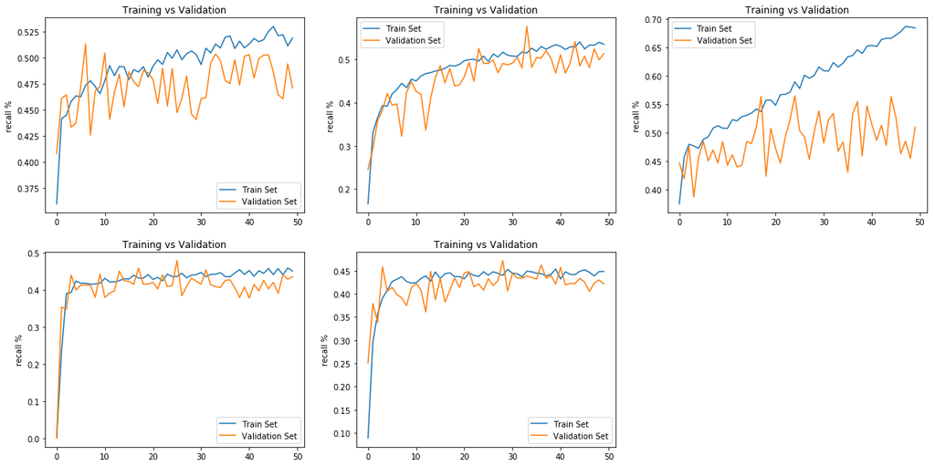

```python
%matplotlib inline


plt.figure(figsize=(20,10))
plt.subplot(2, 3, 1)
plt.plot(history_1.history['recall_m'], label='Train Set')
plt.ylabel('recall %')
plt.title('Training vs Validation')
plt.plot(history_1.history['val_recall_m'], label='Validation Set')
plt.legend()

plt.subplot(2, 3, 2)
plt.plot(history_2.history['recall_m'], label='Train Set')
plt.ylabel('recall %')
plt.title('Training vs Validation')
plt.plot(history_2.history['val_recall_m'], label='Validation Set')
plt.legend()

plt.subplot(2, 3, 3)
plt.plot(history_3.history['recall_m'], label='Train Set')
plt.ylabel('recall %')
plt.title('Training vs Validation')
plt.plot(history_3.history['val_recall_m'], label='Validation Set')
plt.legend()

plt.subplot(2, 3, 4)
plt.plot(history_4.history['recall_m'], label='Train Set')
plt.ylabel('recall %')
plt.title('Training vs Validation')
plt.plot(history_4.history['val_recall_m'], label='Validation Set')
plt.legend()

plt.subplot(2, 3, 5)
plt.plot(history_5.history['recall_m'], label='Train Set')
plt.ylabel('recall %')
plt.title('Training vs Validation')
plt.plot(history_5.history['val_recall_m'], label='Validation Set')
plt.legend()
```

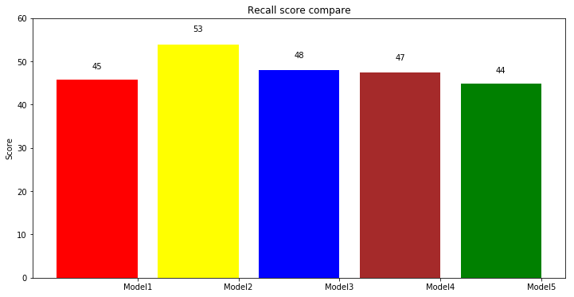

```python
method=['Model1','Model2','Model3','Model4','Model5']
recall_score_compare=[45.7,53.8,48,47.5,44.8]
# plt.hist(method, time_compare)
# plt.show()
import matplotlib.pyplot as plt

x = [0,1,2,3,4]
width = 0.8 # width of the bars

def autolabel(rects):
    # attach some text labels
    for rect in rects:
        height = rect.get_height()
        ax.text(rect.get_x() + rect.get_width()/2., 1.05*height,
                '%d' % float(height),
                ha='center', va='bottom')

fig, ax = plt.subplots(figsize=(12,6))
color=['red', 'yellow', 'blue', 'brown', 'green']
rects1 = ax.bar(x, recall_score_compare, width, color=color)

ax.set_ylim(0,60)
ax.set_ylabel('Score')
ax.set_title('Recall score compare')
ax.set_xticks(np.add(x,(width/2))) # set the position of the x ticks
ax.set_xticklabels(method)
autolabel(rects1)
plt.show()
```

### Recall score history - - Training vs Validation

First Model: Three layers of deep network. Three pairs of two features crossed columnswide network

Second Model: Five layers of deep network. Same wide network as first.

Third Model: Seven layers of deep network. Same wide network as first.

Fourth Model: Five layers of deep network. Same wide network as first. Add L2 and dropout to Deep network.

Fifth Model: Five layers of deep network. Two pairs of three features crossed columns. Add L2 and dropout to Deep network.

From second graph we see the performance among Model 1(3 layers),Model 2 (5 layers), Model 3(7 layers). Model 2 has the highest performance according to our recall metrics. In the first graph we can clearly see that in model 2, validation set and training set share a trend of increasing. Actually, the performance already reaches peak around epoch 34. The first model shows sign of overfitting after 20 epochs.Model 3 has an even more serious problem of overfitting. After epoch 16, the validation set has completely separate itself with training set, whose score continously increase.

Model 4 and Model 5 shows the power of dropout and L2, they effectively keep the validation set score and training set score close. However, according to the score plot, they perform worse than Model 2, which does not use dropout nor L2. My assumption is that if we could train Model 4 and Model 5 more epochs and adjust the parameters of dropout layer and L2, we can make them perform better and have a lower risk of overfitting.

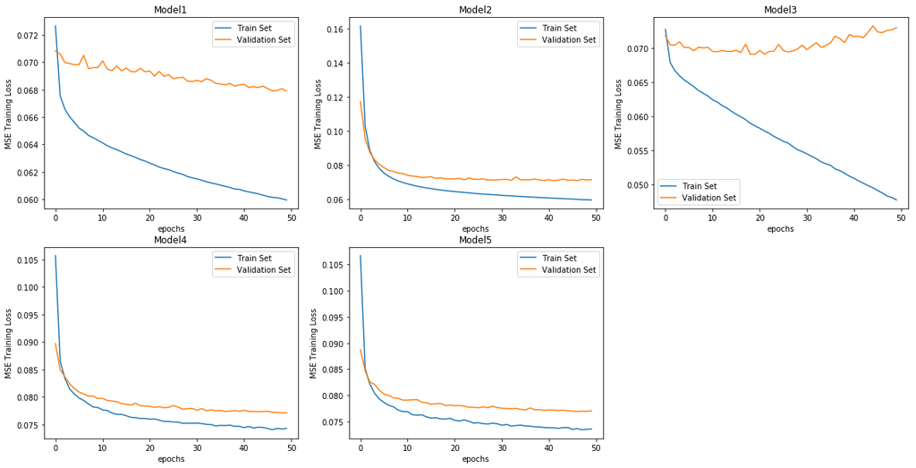

```python
%matplotlib inline

plt.figure(figsize=(20,10))
plt.subplot(2, 3, 1)

plt.plot(history_1.history['loss'],label='Train Set')
plt.legend()
plt.title('Model1')
plt.ylabel('MSE Training Loss')
plt.xlabel('epochs')
plt.plot(history_1.history['val_loss'], label='Validation Set')
plt.legend()

plt.subplot(2, 3, 2)
plt.plot(history_2.history['loss'],label='Train Set')
plt.legend()
plt.title('Model2')
plt.ylabel('MSE Training Loss')
plt.xlabel('epochs')
plt.plot(history_2.history['val_loss'], label='Validation Set')
plt.legend()

plt.subplot(2, 3, 3)
plt.plot(history_3.history['loss'],label='Train Set')
plt.legend()
plt.title('Model3')
plt.ylabel('MSE Training Loss')
plt.xlabel('epochs')
plt.plot(history_3.history['val_loss'], label='Validation Set')
plt.legend()

plt.subplot(2, 3, 4)
plt.plot(history_4.history['loss'],label='Train Set')
plt.legend()
plt.title('Model4')
plt.ylabel('MSE Training Loss')
plt.xlabel('epochs')
plt.plot(history_4.history['val_loss'], label='Validation Set')
plt.legend()

plt.subplot(2, 3, 5)
plt.plot(history_5.history['loss'],label='Train Set')
plt.legend()
plt.title('Model5')
plt.ylabel('MSE Training Loss')
plt.xlabel('epochs')
plt.plot(history_5.history['val_loss'], label='Validation Set')
plt.legend()
```

### MSE training loss history - - Training vs Validation

First Model: Three layers of deep network. Three pairs of two features crossed columnswide network

Second Model: Five layers of deep network. Same wide network as first.

Third Model: Seven layers of deep network. Same wide network as first.

Fourth Model: Five layers of deep network. Same wide network as first. Add L2 and dropout to Deep network.

Fifth Model: Five layers of deep network. Two pairs of three features crossed columns. Add L2 and dropout to Deep network.

This plot can help better explain our previous thoughts on these five models. Model 1 and Model 3 have a large deviation between training set and validation set. Model 3 even shows the tendency of loss increasing. Model 2, without the aid of dropout and L2, suprisingly shows the best performance. As Model 2, 4, 5 seems reach their peak performance, they have converged.

### Fight with MLP

Compare the performance of your best wide and deep network to a standard multi-layer perceptron (MLP). For classification tasks, use the receiver operating characteristic and area under the curve.

```python
from keras.models import Sequential
from keras.layers import Dropout, Dense

model_mlp = Sequential()
model_mlp.add(Dense(10, input_dim=16, activation='sigmoid'))
model_mlp.add(Dropout(0.5))
model_mlp.add(Dense(10, activation='relu'))
model_mlp.add(Dropout(0.5))
model_mlp.add(Dense(1, activation='sigmoid'))

model_mlp.compile(loss='binary_crossentropy',
             optimizer='rmsprop',
              metrics=[recall_m])


model_mlp.fit(X_train, y_train,
         epochs=50,
         batch_size=32)

# score = model_mlp.evaluate(X_test, y_test, batch_size=32)
```

```
WARNING:tensorflow:From C:\Users\54149\Miniconda3\lib\site-packages\keras\backend\tensorflow_backend.py:3445: calling dropout (from tensorflow.python.ops.nn_ops) with keep_prob is deprecated and will be removed in a future version.
Instructions for updating:
Please use `rate` instead of `keep_prob`. Rate should be set to `rate = 1 - keep_prob`.
```

```
<keras.callbacks.History at 0x275fafb0a20>
```

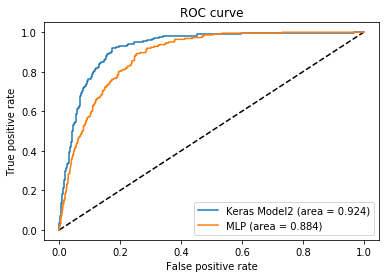

```python
from matplotlib import pyplot as plt
from sklearn.metrics import roc_curve
y_pred_keras = model_2.predict(X_ints_test_2 + [X_test_num]).ravel()
fpr_keras, tpr_keras, thresholds_keras = roc_curve(y_test, y_pred_keras)

y_pred_mlp = model_mlp.predict(X_test).ravel()
fpr_mlp, tpr_mlp, thresholds_mlp = roc_curve(y_test, y_pred_mlp)


from sklearn.metrics import auc
auc_keras = auc(fpr_keras, tpr_keras)
auc_mlp = auc(fpr_mlp, tpr_mlp)

plt.plot([0, 1], [0, 1], 'k--')
plt.plot(fpr_keras, tpr_keras, label='Keras Model2 (area = {:.3f})'.format(auc_keras))
plt.plot(fpr_mlp, tpr_mlp, label='MLP (area = {:.3f})'.format(auc_mlp))

plt.xlabel('False positive rate')
plt.ylabel('True positive rate')
plt.title('ROC curve')
plt.legend(loc='best')
plt.show()
```

According to the graph showing above, We can clearly see that our Keras network is able to achieve a larger area under the curve than MLP, that means our model is able to learn more from our training data and generalizes better to the validation dataset. Thanks to the wide network our keras model can classify better.

## Extra I

As I discussed above, since this dataset is described as Portugal bank call data, the relationship of the previous call duration and previous campaign result is valuable to our model. I devide the data into 5 intervals which have about 8000-9000 samples and this amount is large enough to be representative. Now I am going to add that feature into our model to see if we can achieve a better performance than Model 2.

```python
df = pd.read_csv('data/bank-full.csv')

df['duration_class']=pd.cut(df['duration'],[-1,90,150,230,380,9999], labels=['very short','slightly short', 'mid','slightly long','very long'])
categorical_headers=['job','marital','education','default','housing','loan','contact','month','poutcome','duration_class']

encoders=dict()
numeric_headers = ["age", "balance", "day","duration","campaign","pdays","previous"]
df['target'] = (df['y'] == 'yes').astype(int)

df_train=df


for col in categorical_headers:
    df_train[col] = df_train[col].str.strip()
        # integer encoded variables
    encoders[col] = LabelEncoder() # save the encoder
    df_train[col+'_int'] = encoders[col].fit_transform(df_train[col])

# scale the numeric, continuous variables

for col in numeric_headers:
    df_train[col] = df_train[col].astype(np.float)

    ss = StandardScaler()
    df_train[col] = ss.fit_transform(df_train[col].values.reshape(-1, 1))

df_train.head()
categorical_headers_ints = [x+'_int' for x in categorical_headers]
print(df.groupby('duration_class').size())
```

```
duration_class
mid               9228
slightly long     8784
slightly short    9321
very long         8589
very short        9289
dtype: int64
```

```python
from sklearn.model_selection import train_test_split

print(df.shape)
df_y=df.target

# split original data to train and test
train, test = train_test_split(df,test_size=0.2,random_state=0)

# split original test data to validation data and test data
validation, test = train_test_split(test,test_size=0.2,random_state=0)

df_train=pd.DataFrame(train)
df_validation=pd.DataFrame(validation)
df_test=pd.DataFrame(test)

feature_columns = categorical_headers_ints+numeric_headers
X_train =  ss.fit_transform(df_train[feature_columns].values).astype(np.float32)
X_validation = ss.transform(df_validation[feature_columns].values).astype(np.float32)
X_test =  ss.transform(df_test[feature_columns].values).astype(np.float32)

y_train = df_train['target'].values.astype(np.int)
y_validation = df_validation['target'].values.astype(np.int)
y_test = df_test['target'].values.astype(np.int)

print(feature_columns)

X_train_num =  df_train[numeric_headers].values
X_validation_num = df_validation[numeric_headers].values
X_test_num = df_test[numeric_headers].values
```

```
(45211, 29)
['job_int', 'marital_int', 'education_int', 'default_int', 'housing_int', 'loan_int', 'contact_int', 'month_int', 'poutcome_int', 'duration_class_int', 'age', 'balance', 'day', 'duration', 'campaign', 'pdays', 'previous']
```

```python
new_cross_columns = [['education','job'],
                 ['housing', 'job'],
                 ['default','job'],
                 ['duration_class','poutcome']]

embed_branches = []
X_ints_train_6 = []
X_ints_validation_6 = []
X_ints_test_6 = []
all_inputs_6 = []
all_wide_branch_outputs_6 = []

for cols in new_cross_columns:
    # encode crossed columns as ints for the embedding
    enc = LabelEncoder()

    # create crossed labels
    X_crossed_train = df_train[cols].apply(lambda x: '_'.join(x), axis=1)
    X_crossed_validation = df_validation[cols].apply(lambda x: '_'.join(x), axis=1)
    X_crossed_test = df_test[cols].apply(lambda x: '_'.join(x), axis=1)

    enc.fit(np.hstack((X_crossed_train.values,  X_crossed_validation.values)))
    X_crossed_train = enc.transform(X_crossed_train)
    X_crossed_validation = enc.transform(X_crossed_validation)
    X_crossed_test = enc.transform(X_crossed_test)
    X_ints_train_6.append( X_crossed_train )
    X_ints_validation_6.append(X_crossed_validation)
    X_ints_test_6.append( X_crossed_test )

    # get the number of categories
    N = max(X_ints_train_6[-1]+1) # same as the max(df_train[col])

    # create embedding branch from the number of categories
    inputs = Input(shape=(1,),dtype='int32', name = '_'.join(cols))
    all_inputs_6.append(inputs)
    x = Embedding(input_dim=N,
                  output_dim=int(np.sqrt(N)),
                  input_length=1, name = '_'.join(cols)+'_embed')(inputs)
    x = Flatten()(x)
    all_wide_branch_outputs_6.append(x)

# merge the branches together
wide_branch = concatenate(all_wide_branch_outputs_6, name='wide_concat')
wide_branch = Dense(units=1,activation='sigmoid',name='wide_combined')(wide_branch)

# reset this input branch
all_deep_branch_outputs = []
# add in the embeddings
for col in categorical_headers_ints:
    # encode as ints for the embedding
    X_ints_train_6.append( df_train[col].values )
    X_ints_validation_6.append(df_validation[col].values)
    X_ints_test_6.append( df_test[col].values )

    # get the number of categories
    N = max(X_ints_train_6[-1]+1) # same as the max(df_train[col])

    # create embedding branch from the number of categories
    inputs = Input(shape=(1,),dtype='int32', name=col)
    all_inputs_6.append(inputs)
    x = Embedding(input_dim=N,
                  output_dim=int(np.sqrt(N)),
                  input_length=1, name=col+'_embed')(inputs)
    x = Flatten()(x)
    all_deep_branch_outputs.append(x)

# also get a dense branch of the numeric features
all_inputs_6.append(Input(shape=(X_train_num.shape[1],),
                        sparse=False,
                        name='numeric_data'))

x = Dense(units=20, activation='relu',name='numeric_1')(all_inputs_6[-1])
all_deep_branch_outputs.append( x )

# merge the deep branches together
deep_branch = concatenate(all_deep_branch_outputs,name='concat_embeds')
deep_branch = Dense(units=75,activation='relu', name='deep2')(deep_branch)
deep_branch = Dense(units=50,activation='relu', name='deep3')(deep_branch)
deep_branch = Dense(units=25,activation='relu', name='deep5')(deep_branch)
deep_branch = Dense(units=10,activation='relu', name='deep6')(deep_branch)
deep_branch = Dense(units=5,activation='relu', name='deep7')(deep_branch)

final_branch = concatenate([wide_branch, deep_branch],name='concat_deep_wide')
final_branch = Dense(units=1,activation='sigmoid',name='combined')(final_branch)

model_6 = Model(inputs=all_inputs_6, outputs=final_branch)
```

```python
model_6.compile(optimizer='adagrad',
              loss='mean_squared_error',
              metrics=[recall_m])

history_6 = model_6.fit(X_ints_train_6+ [X_train_num],
                    y_train,
                    epochs=50,
                    batch_size=32,
                    verbose=1,
                    validation_data = (X_ints_validation_6 + [X_validation_num], y_validation))
```

```
Train on 36168 samples, validate on 7234 samples
```

```python
from sklearn import metrics as mt
yhat_6 = np.round(model_6.predict(X_ints_test_6 + [X_test_num]))
print(mt.confusion_matrix(y_test,yhat_6))

print(mt.recall_score(y_test,yhat_6))
```

```
[[1510   76]
 [ 107  116]]
0.5201793721973094
```

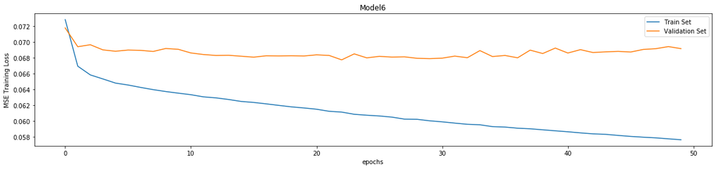

```python
import matplotlib.pyplot as plt

plt.figure(figsize=(20,4))

plt.plot(history_6.history['loss'],label='Train Set')
plt.legend()
plt.title('Model6')
plt.ylabel('MSE Training Loss')
plt.xlabel('epochs')
plt.plot(history_6.history['val_loss'], label='Validation Set')
plt.legend()
```

Despite that the MSE loss plot indicates that this model starts to overfit since epoch 10. The performance evaluated by our recall metric is very good; This model gain 0.52 score, which is better than any previous models except Model2. Now I make another model which is deployed with dropout layer and L2 regularization to see if we can reduce the negative effect of overfitting.

```python
from keras import regularizers
from keras.layers import Dropout
new_cross_columns = [['education','job'],
                 ['housing', 'job'],
                 ['default','job'],
                 ['duration_class','poutcome']]

embed_branches = []
X_ints_train_7 = []
X_ints_validation_7 = []
X_ints_test_7 = []
all_inputs_7 = []
all_wide_branch_outputs_7 = []

for cols in new_cross_columns:
    # encode crossed columns as ints for the embedding
    enc = LabelEncoder()

    # create crossed labels
    X_crossed_train = df_train[cols].apply(lambda x: '_'.join(x), axis=1)
    X_crossed_validation = df_validation[cols].apply(lambda x: '_'.join(x), axis=1)
    X_crossed_test = df_test[cols].apply(lambda x: '_'.join(x), axis=1)

    enc.fit(np.hstack((X_crossed_train.values,  X_crossed_validation.values)))
    X_crossed_train = enc.transform(X_crossed_train)
    X_crossed_validation = enc.transform(X_crossed_validation)
    X_crossed_test = enc.transform(X_crossed_test)
    X_ints_train_7.append( X_crossed_train )
    X_ints_validation_7.append(X_crossed_validation)
    X_ints_test_7.append( X_crossed_test )

    # get the number of categories
    N = max(X_ints_train_7[-1]+1) # same as the max(df_train[col])

    # create embedding branch from the number of categories
    inputs = Input(shape=(1,),dtype='int32', name = '_'.join(cols))
    all_inputs_7.append(inputs)
    x = Embedding(input_dim=N,
                  output_dim=int(np.sqrt(N)),
                  input_length=1, name = '_'.join(cols)+'_embed')(inputs)
    x = Flatten()(x)
    all_wide_branch_outputs_7.append(x)

# merge the branches together
wide_branch = concatenate(all_wide_branch_outputs_7, name='wide_concat')
wide_branch = Dense(units=1,activation='sigmoid',name='wide_combined')(wide_branch)

# reset this input branch
all_deep_branch_outputs = []
# add in the embeddings
for col in categorical_headers_ints:
    # encode as ints for the embedding
    X_ints_train_7.append( df_train[col].values )
    X_ints_validation_7.append(df_validation[col].values)
    X_ints_test_7.append( df_test[col].values )

    # get the number of categories
    N = max(X_ints_train_7[-1]+1) # same as the max(df_train[col])

    # create embedding branch from the number of categories
    inputs = Input(shape=(1,),dtype='int32', name=col)
    all_inputs_7.append(inputs)
    x = Embedding(input_dim=N,
                  output_dim=int(np.sqrt(N)),
                  input_length=1, name=col+'_embed')(inputs)
    x = Flatten()(x)
    all_deep_branch_outputs.append(x)

# also get a dense branch of the numeric features
all_inputs_7.append(Input(shape=(X_train_num.shape[1],),
                        sparse=False,
                        name='numeric_data'))

x = Dense(units=20, activation='relu',name='numeric_1')(all_inputs_7[-1])
all_deep_branch_outputs.append( x )

# merge the deep branches together
deep_branch = concatenate(all_deep_branch_outputs,name='concat_embeds')
deep_branch = Dense(units=75,activation='relu', name='deep1', kernel_regularizer=regularizers.l2(0.0001))(deep_branch)
deep_branch = Dropout(0.1, seed=1)(deep_branch)
deep_branch = Dense(units=50,activation='relu', name='deep2', kernel_regularizer=regularizers.l2(0.0001))(deep_branch)
deep_branch = Dropout(0.1, seed=2)(deep_branch)
deep_branch = Dense(units=25,activation='relu', name='deep3', kernel_regularizer=regularizers.l2(0.0001))(deep_branch)
deep_branch = Dropout(0.1, seed=2)(deep_branch)
deep_branch = Dense(units=10,activation='relu', name='deep4', kernel_regularizer=regularizers.l2(0.0001))(deep_branch)
deep_branch = Dropout(0.1, seed=2)(deep_branch)
deep_branch = Dense(units=5,activation='relu', name='deep5', kernel_regularizer=regularizers.l2(0.0001))(deep_branch)

final_branch = concatenate([wide_branch, deep_branch],name='concat_deep_wide')
final_branch = Dense(units=1,activation='sigmoid',name='combined')(final_branch)

model_7 = Model(inputs=all_inputs_7, outputs=final_branch)
```

```
WARNING:tensorflow:From C:\Users\54149\Miniconda3\lib\site-packages\keras\backend\tensorflow_backend.py:3445: calling dropout (from tensorflow.python.ops.nn_ops) with keep_prob is deprecated and will be removed in a future version.
Instructions for updating:
Please use `rate` instead of `keep_prob`. Rate should be set to `rate = 1 - keep_prob`.
```

```python
model_7.compile(optimizer='adagrad',
              loss='mean_squared_error',
              metrics=[recall_m])

history_7 = model_7.fit(X_ints_train_7+ [X_train_num],
                    y_train,
                    epochs=50,
                    batch_size=32,
                    verbose=1,
                    validation_data = (X_ints_validation_7 + [X_validation_num], y_validation))
```

```
Train on 36168 samples, validate on 7234 samples
```

```python
yhat_7 = np.round(model_7.predict(X_ints_test_7 + [X_test_num]))
print(mt.confusion_matrix(y_test,yhat_7))

print(mt.recall_score(y_test,yhat_7))
```

```
[[1508   78]
 [ 105  118]]
0.5291479820627802
```

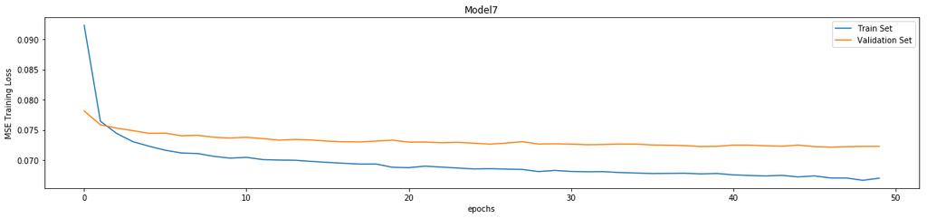

```python
plt.figure(figsize=(20,4))

plt.plot(history_7.history['loss'],label='Train Set')
plt.legend()
plt.title('Model7')
plt.ylabel('MSE Training Loss')
plt.xlabel('epochs')
plt.plot(history_7.history['val_loss'], label='Validation Set')
plt.legend()
```